Even though I have already deduced that linear regression is not appropriate for quantifying monotonicity with small samples of ordinal data, I still wondered what kind of results it might produce. Also, I figured that this might be a good opportunity to practice the [“many models”](http://r4ds.had.co.nz/many-models.html) approach discussed in the [*R For Data Science* book](http://r4ds.had.co.nz/) and refine my skills with the [`purrr` package](http://purrr.tidyverse.org/), the [`broom` package](https://github.com/tidyverse/broom), and the “nest-mutate-unnest” idiom for working with list-columns. (I really enjoyed [this blog post breaking down variations of this idiom](https://coolbutuseless.bitbucket.io/2018/03/03/split-apply-combine-my-search-for-a-replacement-for-group_by---do/).)

## Experimentation with Linear Regression

Having realized that an “out-of-the-box” linear regression approach will not be useful, I’ll try a couple different variations of transforming the data. In particular, I’ll evaluate linear models after transforming the data in four different ways:

1. Re-scaling the x- and y-ranks to the range `[0, 1]`. (This seems like the best approach to me, but I’m not sure.)
2. Re-scaling to the range `[-1, 1]`. (This seems like it might generate similar results the previous method, but perhaps it is “more accurate” for representing values that may be negative.)
3. Re-scaling to the range `[1, 2 * n]` (I would not really bother attempting this in a non-experimental setting because it needlessly magnifies the range. Nonetheless, I am curious to see how the estimation of coefficients and p-values changes.)
4. Re-scaling to the range `[-2 * n, 2 * n]`. (As with the previous method, I would not really try this if I were serious, but I’m curious to see what it turns out.)

Note(s) on the code chunk below:

- I use the `purrr::partial()` function to reduce code redundancy.
- I tend to prefer `dplyr::mutate_at()` (compared to `dplyr::mutate()`) in all situations where I am transforming variables in a data.frame, even if I am simply transforming a single variable. It offers a ton of flexibility when applying multiple functions across multiple columns.

```r
rescale1 <- purrr::partial(scales::rescale, to = c(0, 1))
rescale2 <- purrr::partial(scales::rescale, to = c(-1, 1))
rescale3 <- purrr::partial(scales::rescale, to = c(1, 2 * n))
rescale4 <- purrr::partial(scales::rescale, to = c(-2 * n, 2 * n))
data <-
  data_permns %>%
  group_by(grp) %>%
  mutate_at(
    vars(x0),
    funs(
      # x1 = scales::rescale(., to = c(0, 1)),
      x1 = rescale1,
      x2 = rescale2,
      x3 = rescale3,
      x4 = rescale4
    )
  ) %>%
  mutate_at(
    vars(y0),
    funs(
      y1 = rescale1,
      y2 = rescale2,
      y3 = rescale3,
      y4 = rescale4
    )
  ) %>%
  ungroup() %>%
  arrange(grp)
```

Now, after transforming the data, I can begin to implement the “many models” approach, beginning with model fitting.

Note(s) on the code chunk below:

- This is another ideal case for using `purrr::partial()`. (Unfortunately, I could not quite figure out how to eliminate the redundancy with the explicit formulas.)
- I choose (perhaps foolishly) to not include an intercept term in the models because, theoretically, if the data is monotonic, the model should estimate the slope to be 1 and the intercept to be 0. Thus, when the data is not actually monotonic, I can roughly estimate the relationship of the predictor and the response variables by how much the estimated slope differs from 1, given that the intercept is held constant at 0. (This line of thinking may be completely nonsensical to the reader, but it makes sense to me.)

```r
partial_fit <- purrr::partial(purrr::map, .f = lm)
fit <-
  data %>%
  group_by(grp) %>%
  nest() %>%
  mutate(
    # fit0 = purrr::map(data_xy, ~lm(y0 ~ x0 + 0, data_xy = .x)),
    fit0 = partial_fit(data, formula = as.formula(y0 ~ x0 + 0)),
    fit1 = partial_fit(data, formula = as.formula(y1 ~ x1 + 0)),
    fit2 = partial_fit(data, formula = as.formula(y2 ~ x3 + 0)),
    fit3 = partial_fit(data, formula = as.formula(y2 ~ x3 + 0)),
    fit4 = partial_fit(data, formula = as.formula(y4 ~ x4 + 0))
  )
```

Next, I can easily extract the slope of each univariate model.

Note(s) on the code chunk below:

- Because I’ve chosen not to include an intercept in any of the models, each only has one term.
- I use `round(., 4)` to prevent the p-value from printing out with 10+ decimal places for those models where the fit is nearly exact.

```r
partial_tidy <- purrr::partial(purrr::map, .f = broom::tidy)
terms <-
  fit %>%
  mutate(
    # tidy0 = purrr::map(fit0, broom::tidy),
    tidy0 = partial_tidy(fit0),
    tidy1 = partial_tidy(fit1),
    tidy2 = partial_tidy(fit2),
    tidy3 = partial_tidy(fit3),
    tidy4 = partial_tidy(fit4)
  ) %>%
  unnest(tidy0, tidy1, tidy2, tidy3, tidy4, .drop = TRUE) %>%
  select(matches("grp|estimate|p\\.value")) %>%
  mutate_if(is.numeric, funs(round(., 4)))
terms %>% glimpse()
```

```
## Observations: 576
## Variables: 11
## $ grp       <chr> "x1234y1234", "x1234y1243", "x1234y1324", "x1234y134...
## $ estimate  <dbl> 1.0000, 0.9667, 0.9667, 0.9000, 0.9000, 0.8667, 0.96...
## $ p.value   <dbl> 0.0000, 0.0073, 0.0073, 0.0374, 0.0374, 0.0573, 0.00...
## $ estimate1 <dbl> 1.0000, 0.9286, 0.9286, 0.7857, 0.7857, 0.7143, 0.92...
## $ p.value1  <dbl> 0.0000, 0.0227, 0.0227, 0.1152, 0.1152, 0.1753, 0.02...
## $ estimate2 <dbl> 0.0719, 0.0575, 0.0575, 0.0287, 0.0287, 0.0144, 0.05...
## $ p.value2  <dbl> 0.3893, 0.5032, 0.5032, 0.7463, 0.7463, 0.8725, 0.50...
## $ estimate3 <dbl> 0.0719, 0.0575, 0.0575, 0.0287, 0.0287, 0.0144, 0.05...
## $ p.value3  <dbl> 0.3893, 0.5032, 0.5032, 0.7463, 0.7463, 0.8725, 0.50...
## $ estimate4 <dbl> 1.0, 0.8, 0.8, 0.4, 0.4, 0.2, 0.8, 0.6, 0.4, -0.2, 0...
## $ p.value4  <dbl> 0.0000, 0.1041, 0.1041, 0.5046, 0.5046, 0.7471, 0.10...
```

Finally, I can extract a one-line summary of each model from the fitted data.

Note(s) on the code chunk below:

- The p.value for the model itself is identical to that for the term. I believe that this is generally true for univariate linear regression models without an intercept.
- I prefer the [adjusted R-squared](http://www.statisticshowto.com/adjusted-r2/) (`adj.r.squared`) over the “regular” R-squared `r.squared` value for summarizing a linear regression model because it attempts to account for the number of terms. (In this case, it does not actually matter because there is only one term.)

```r
partial_glance <- purrr::partial(purrr::map, .f = broom::glance)
summ <-
  fit %>%
  mutate(
    glance0 = partial_glance(fit0),
    glance1 = partial_glance(fit1),
    glance2 = partial_glance(fit2),
    glance3 = partial_glance(fit3),
    glance4 = partial_glance(fit4)
  ) %>%
  unnest(glance0, glance1, glance2, glance3, glance4, .drop = TRUE) %>%
  select(matches("grp|adj.r\\.squared|p\\.value")) %>%
  mutate_if(is.numeric, funs(round(., 4)))
summ %>% glimpse()
```

```
## Observations: 576
## Variables: 11
## $ grp            <chr> "x1234y1234", "x1234y1243", "x1234y1324", "x123...
## $ adj.r.squared  <dbl> 1.0000, 0.9126, 0.9126, 0.7467, 0.7467, 0.6681,...
## $ p.value        <dbl> 0.0000, 0.0073, 0.0073, 0.0374, 0.0374, 0.0573,...
## $ adj.r.squared1 <dbl> 1.0000, 0.8163, 0.8163, 0.4898, 0.4898, 0.3469,...
## $ p.value1       <dbl> 0.0000, 0.0227, 0.0227, 0.1152, 0.1152, 0.1753,...
## $ adj.r.squared2 <dbl> 0.0021, -0.1187, -0.1187, -0.2797, -0.2797, -0....
## $ p.value2       <dbl> 0.3893, 0.5032, 0.5032, 0.7463, 0.7463, 0.8725,...
## $ adj.r.squared3 <dbl> 0.0021, -0.1187, -0.1187, -0.2797, -0.2797, -0....
## $ p.value3       <dbl> 0.3893, 0.5032, 0.5032, 0.7463, 0.7463, 0.8725,...
## $ adj.r.squared4 <dbl> 1.0000, 0.5200, 0.5200, -0.1200, -0.1200, -0.28...
## $ p.value4       <dbl> 0.0000, 0.1041, 0.1041, 0.5046, 0.5046, 0.7471,...
```

What do the distribution of the model slope estimates and p-values for each data transformation look like?

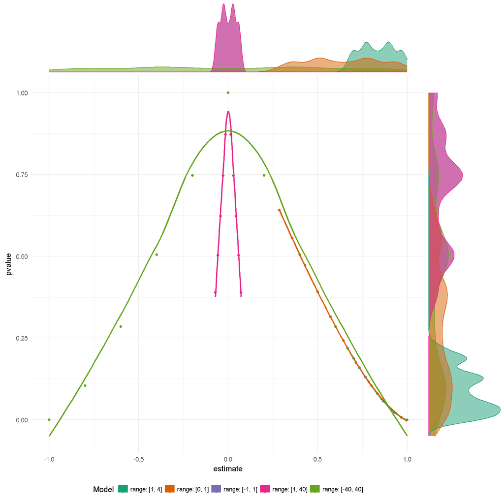

What about for the baseline data transformation?

```r
summ_mntc_mod_0 <-
  summ_mntc %>%
  left_join(
    mod_info_tidy %>%
      filter(mod_id == "0") %>%
      select(-mod_id) %>%
      spread(metric, value),
    by = "grp")
 summ_mntc_mod_0 %>%
   select(matches("mntc|estimate|pvalue|adjrsquared")) %>%
   select_if(is.numeric) %>%
   corrr::correlate()
```

```
## # A tibble: 4 x 5
##   rowname      mntc_distinv adjrsquared estimate   pvalue
##   <chr>               <dbl>       <dbl>    <dbl>    <dbl>
## 1 mntc_distinv      NA           0.9019   0.8948 - 0.8620
## 2 adjrsquared        0.9019     NA        0.9986 - 0.9817
## 3 estimate           0.8948      0.9986  NA      - 0.9903
## 4 pvalue           - 0.8620    - 0.9817 - 0.9903  NA
```

[figure not shown]